# JASA_Realdata_Melanoma_LLM

Ziyi Wang

2026-03-16

# Melanoma anti-PD-1 - The second real data

## Wilcoxon test + LLM

### Load Packages/Functions

```r
suppressPackageStartupMessages({
  library(knitr)
  library(CATMicrobiome)
  library(mvtnorm)
  library(mixtools)
  library(devtools)
  library(KScorrect)
  library(adaptMT)
  library(AdaPTGMM)
  library(splines2)
  library(dplyr)
  library(tibble)
  library(stringr)
  library(ape)
  library(phyloseq)
  library(ggplot2)
  library(tidyr)
  library(coin)
  library(ggrepel)
  library(IHW)
  library(FDRreg)
  library(OrderShapeEM)
  library(chai)
})
```

### Load the data and pre-processing the data

**Note**: The pro-processing part and model fitting chunk could be time-consuming. We saved the processed data together with the organized results after fitting the models. When knitting this HTML file, we loaded the **Gopalakrishnan_16s_LLM_env.RData** file directly and generated the plots from it.

However, for verification or reproducibility, you can also run each pre-processing chunk and/or model-fitting chunk one by one, while skiping the chunk that loads the .RData file. This should produce the same results.

```r
#################### Load data from package CATMicrobiome ##############
otuPath <- system.file("extdata","d1OTUtable.csv",
                       package = "CATMicrobiome")
otutable <- read.csv(otuPath,header=TRUE,row.names = 1)

taxonomyPath <- system.file("extdata","d1Taxonomy.csv",
                            package = "CATMicrobiome")
taxonomy <- read.csv(taxonomyPath,header=TRUE,row.names = 1)

metaPath <- system.file("extdata","d1Meta.csv",
                        package = "CATMicrobiome")
metaData <- read.csv(metaPath,header=TRUE,row.names = 1)

treePath <- system.file("extdata","d1Tree.tree",
                        package = "CATMicrobiome")
tree <- read.tree(treePath)

otus_tree   <- tree$tip.label       # 1437
otus_tax    <- rownames(taxonomy)   # 1455
otus_keep   <- intersect(otus_tree, otus_tax)   # Keep 1437

# Prune tree and taxonomy
tree <- keep.tip(tree, otus_keep)
taxonomy <- taxonomy[otus_keep, , drop = FALSE]
taxonomy <- taxonomy[match(tree$tip.label, rownames(taxonomy)), , drop = FALSE]  # reorder to tree tips
otutable <- otutable[otus_keep, , drop = FALSE]
# 1437 tips

OTU <- otu_table(as.matrix(otutable), taxa_are_rows = TRUE)
TAX <- tax_table(as.matrix(taxonomy))
SAM <- sample_data(metaData)
TR  <- phy_tree(tree)

############### Build phyloseq-class objects ################
ps <- phyloseq(OTU, TAX, SAM, TR)

###################### Aggregate into Family level #######################
family <- tax_glom(ps, taxrank='family')

###################### Abundance table #######################
# family
cs <- colSums(otu_table(family))
cs[cs == 0] <- 1
family_abun <- sweep(otu_table(family), 2, cs, "/") * 100
t_family_abun <- t(family_abun)     # 43 x 76

########################## Outcome ###################################
# Check the metadata order matching to the abundance subject order
rownames(sample_data(family)) == rownames(t_family_abun)

outcome <- factor(sample_data(family)$BinOutcomes, levels = c("NR","R"))
table(outcome)
```

### Generating the p-value/z-value

```r
# Define a function to compute the z-value and p-value
compute_pz_wilcox <- function(t_abun, outcome) {
  stopifnot(nrow(t_abun) == length(outcome))

  p_z_values <- sapply(colnames(t_abun), function(feature) {
    features <- t_abun[, feature, drop = FALSE]
    wilcox <- wilcox_test(features[, 1] ~ outcome)

    c(
      p_value = as.numeric(pvalue(wilcox)),
      z_value = as.numeric(statistic(wilcox))
    )
  }, simplify = "matrix")
  p_z_values <- as.data.frame(t(p_z_values))
  p_z_values$feature <- rownames(p_z_values)
  rownames(p_z_values) <- NULL

  return(p_z_values)
}

# family's p-value and z-value
family_pz <- compute_pz_wilcox(t_family_abun, outcome)
```

### Combine the p-value/z-value with corresponding abundance table

```r
#################### Build OTU for family level #####################
# Define a function to clean the feature name
clean_taxon <- function(x) {
  x %>%
    as.character() %>%
    str_replace("^.*?__", "") %>%        # Remove k__/f__/g__
    str_replace_all("\\[|\\]", "") %>%   # Remove []
    str_squish()                         # Remove extra space
}

# Define a function that can combine the right rank tables together
make_main_df <- function(t_abun, pz_df, ps_obj, rank) {
  # rank: the tax_table column you want to join on, e.g. "family" / "genus" / "order" / "class"

  tax_df <- as.data.frame(tax_table(ps_obj)) %>%
    rownames_to_column("otu_rep")

  # find the taxonomy column robustly (case-insensitive)
  rank_col <- names(tax_df)[tolower(names(tax_df)) == tolower(rank)]
  if (length(rank_col) != 1) {
    stop("Could not uniquely find taxonomy column for rank = '", rank, "'. ",
         "Available columns: ", paste(names(tax_df), collapse = ", "))
  }

  tax_map <- tax_df %>%
    transmute(
      otu_rep,
      rank_value = as.character(.data[[rank_col]])
    )

  # p/z mapping (supports either pz_df$feature or assumes same order as colnames(t_abun))
  pz_map <- if ("feature" %in% names(pz_df)) {
    pz_df %>%
      transmute(
        otu_rep = feature,
        p_main  = as.numeric(p_value),
        z_main  = as.numeric(z_value)
      )
  } else {
    data.frame(
      otu_rep = colnames(t_abun),
      p_main  = as.numeric(pz_df$p_value),
      z_main  = as.numeric(pz_df$z_value),
      stringsAsFactors = FALSE
    )
  }

  main_df <- pz_map %>%
    left_join(tax_map, by = "otu_rep") %>%
    mutate(taxon_key = clean_taxon(rank_value))

  main_df
}

# Generate the family level data frame
family_pz_tax = make_main_df(t_abun = t_family_abun,  pz_df = family_pz,
                             ps_obj = family,  rank = "family")
```

### Load LLM results at family level and pre-processing

```r
library(readr)
library(auctestr)

class_aux_otu <- read_csv("./LLM/d1Taxonomy_OTU_ABCD_class_and_below.csv")

# Aggregation using stouffer_z, only stouffer non-zero values
stouffer_nonzero <- function(v) {
  v2 <- v[!is.na(v) & v != 0]
  if (length(v2) == 0) return(0)
  stouffer_z(v2, ignore.na = FALSE)
}

level <- "family"
cla_ag_fam <- class_aux_otu %>%
  filter(!is.na(.data[[level]]), .data[[level]] != "") %>%
  group_by(.data[[level]]) %>%
  summarise(
    across(
      .cols  = c(A, B, C, D),
      .fns   = stouffer_nonzero,
      .names = "x{col}"
    ),
    .groups = "drop"
  ) %>%
  mutate(taxon_key = clean_taxon(.data[[level]]))


df_model <- family_pz_tax %>%
  dplyr::left_join(cla_ag_fam %>% dplyr::select(taxon_key, xA, xB, xC),
            by = "taxon_key")

z <- df_model$z_main
p <- df_model$p_main
X <- df_model[, c("xA", "xB", "xC")]
```

##### Load the processed data

The processed data included:

- **t_family_abun**: the relative abundance table of this dataset at family level
- **df_model**: saved z-value, p-value, side information, and corresponding OTU name and taxon name
- **outcome**: the outcome (NR or R) of this dataset
- **z**: the z-statistics from wilcoxon text of each family between NR vs R. Same as df_model$z_main
- **p**: the p-value calculated from z-statistics with two-sided. Same as df_model$p_main
- **X**: the side information which included “xA”, “xB”, and “xC” three columns
- **chai_family_llm**: (chai) output with z and X as input
- **LLM_fam_classandbelow**: the summary table saving the number of selections of every method at different q

```r
load("./chai_env/Gopalakrishnan_16s_LLM_env.RData")
```

### Fit the models

```r
q_levels <- seq(0.01, 0.10, by = 0.01)

########################## chai ################################
set.seed(123)
chai_family_llm <- chai(z, X, B = 100)
chai_rejs <- sapply(q_levels, function(q) {
  length(clfdrselect(chai_family_llm$clFDR, q, 1))
})

########################## Adapt-glm ##########################
x <- data.frame(X)
formula_ns <- list(
  ~ ns(xA, df=2) + ns(xB, df=2) + ns(xC, df=2),
  ~ ns(xA, df=4) + ns(xB, df=4) + ns(xC, df=4),
  ~ ns(xA, df=6) + ns(xB, df=6) + ns(xC, df=6)
)

glm_ns <- adapt_glm(x, pvals = p, alphas=q_levels,
                    pi_formulas = formula_ns, mu_formulas = formula_ns)
adapt_glm_ns_rej <- glm_ns$nrejs[1:10]

########################## Adapt-gmm-p ##########################
gmm_ns_p <- adapt_gmm(x, pvals = p,  alphas=q_levels,
                      beta_formulas = formula_ns)
adapt_gmm_p_ns_rej <- gmm_ns_p$nrejs[1:10]

########################## Adapt-gmm-z ##########################
gmm_ns_z <- adapt_gmm(x, z = z, alphas=q_levels,
                      beta_formulas = formula_ns, testing = "two_sided")
adapt_gmm_z_ns_rej <- gmm_ns_z$nrejs[1:10]

########################## OrderShapeEM ##########################
ordershape_x1 <- OrderShapeEM(pvals = p, order.var = X[,1],
                              OrderShapeEM.control(trace = TRUE))
ordershapeem_x1_rejs <- sapply(q_levels, function(q) {
  sum(ordershape_x1$fdr <= q)
})

ordershape_x2 <- OrderShapeEM(pvals = p, order.var = X[,2],
                              OrderShapeEM.control(trace = TRUE))
ordershapeem_x2_rejs <- sapply(q_levels, function(q) {
  sum(ordershape_x2$fdr <= q)
})

ordershape_x3 <- OrderShapeEM(pvals = p, order.var = X[,3],
                              OrderShapeEM.control(trace = TRUE))
ordershapeem_x3_rejs <- sapply(q_levels, function(q) {
  sum(ordershape_x3$fdr <= q)
})

########################## FDRreg ##########################
set.seed(123)
fdr_theo <- FDRreg(z, as.matrix(X), nulltype = 'theoretical')
rdrreg_rejs <- sapply(q_levels, function(q) {
  length(which(fdr_theo$FDR <= q))
})

########################## IHW ##########################
set.seed(123)
ihw_1_rejs <- sapply(q_levels, function(q) {
  ihw <- ihw(pvalues = p, covariates = X[,1], alpha = q, nbins = 5)
  rejections(ihw)
})

ihw_2_rejs <- sapply(q_levels, function(q) {
  ihw <- ihw(pvalues = p, covariates = X[,2], alpha = q, nbins = 5)
  rejections(ihw)
})

ihw_3_rejs <- sapply(q_levels, function(q) {
  ihw <- ihw(pvalues = p, covariates = X[,3], alpha = q, nbins = 5)
  rejections(ihw)
})

########################## BH ##########################
p_adjusted <- p.adjust(p, method = "BH")
bh_rejs <- sapply(q_levels, function(q) {
  length(which(p_adjusted <= q))
})

# Combine into data frame
LLM_fam_classandbelow <- data.frame(
  q = q_levels,
  chai = chai_rejs,
  adapt_glm = adapt_glm_ns_rej,
  adapt_gmm_p = adapt_gmm_p_ns_rej,
  adapt_gmm_z = adapt_gmm_z_ns_rej,
  OrderShapeEM_x1 = ordershapeem_x1_rejs,
  OrderShapeEM_x2 = ordershapeem_x2_rejs,
  OrderShapeEM_x3 = ordershapeem_x3_rejs,
  FDRreg = rdrreg_rejs,
  IHW_x1 = ihw_1_rejs,
  IHW_x2 = ihw_2_rejs,
  IHW_x3 = ihw_3_rejs,
  BH = bh_rejs
)

# Converge into long format for visualization purpose
LLM_fam_classandbelow_long <- LLM_fam_classandbelow %>%
  pivot_longer(
    cols = -q,
    names_to = "Method",
    values_to = "Rejections"
  ) %>%
  mutate(Method = as.character(Method))
```

### Visualization

Define the plotting functions

```r
#################### color helpers #######################
blend_color <- function(col, target = "white", amount = 0.4) {
  a <- grDevices::col2rgb(col) / 255
  b <- grDevices::col2rgb(target) / 255
  out <- (1 - amount) * a + amount * b
  grDevices::rgb(out[1,], out[2,], out[3,])
}

variant_shades <- function(base_col, K = 12) {
  grDevices::colorRampPalette(c(
    blend_color(base_col, "white", 0.55),
    base_col,
    blend_color(base_col, "black", 0.25)
  ))(K)
}

make_method_palette <- function(methods, K = 12) {
  fixed <- c(
    chai        = "red",
    adapt_glm   = "#FF7F0E",
    adapt_gmm_z = "#2CA02C",
    adapt_gmm_p = "#9467BD",
    FDRreg      = "#8C564B",
    BH          = "black"
  )

  family_base <- c(
    OrderShapeEM = "#1F77B4",  # blue family
    IHW          = "#17BECF"   # teal family
  )

  ord_shades <- variant_shades(family_base["OrderShapeEM"], K = K)
  ihw_shades <- variant_shades(family_base["IHW"],          K = K)

  methods <- unique(as.character(methods))
  pal <- setNames(rep("#7F7F7F", length(methods)), methods)  # fallback grey

  for (m in methods) {
    if (m %in% names(fixed)) {
      pal[m] <- fixed[m]
      next
    }

    base <- sub("_x\\d+$", "", m)
    idx  <- suppressWarnings(as.integer(sub(".*_x", "", m)))

    if (base %in% names(family_base)) {
      if (is.na(idx)) {
        pal[m] <- family_base[base]  # e.g. "OrderShapeEM" with no suffix
      } else {
        idx <- max(1L, min(idx, K))
        pal[m] <- if (base == "OrderShapeEM") ord_shades[idx] else ihw_shades[idx]
      }
    }
  }

  pal
}

method_order <- function(methods) {
  methods <- unique(as.character(methods))
  core <- c("chai","adapt_glm","adapt_gmm_z","adapt_gmm_p","FDRreg")

  sort_family <- function(base) {
    fam <- methods[grepl(paste0("^", base, "(_x\\d+)?$"), methods)]
    base_present <- base %in% fam
    vars <- fam[grepl("_x\\d+$", fam)]
    if (length(vars)) {
      idx <- suppressWarnings(as.integer(sub(".*_x", "", vars)))
      vars <- vars[order(idx)]
    }
    c(if (base_present) base else character(0), vars)
  }

  out <- c(core, sort_family("OrderShapeEM"), sort_family("IHW"), "BH")
  out <- unique(out)
  out[out %in% methods]
}

################## plotting function (labels, no legend) ###############
library(ggrepel)
library(stringr)

plot_rejections_vs_q <- function(long_table, # title = "Number of Discoveries vs q",
                                 K_variants = 12, x_breaks = NULL,
                                 method_font = 5.5) {

  ord <- method_order(long_table$Method)
  long_table <- long_table %>% mutate(Method = factor(Method, levels = ord))
  pal <- make_method_palette(levels(long_table$Method), K = K_variants)

  endpoints <- long_table %>%
    group_by(Method) %>%
    filter(q == max(q, na.rm = TRUE)) %>%
    slice_tail(n = 1) %>%
    ungroup() %>%
    mutate(label = as.character(Method))

  x_rng   <- range(long_table$q, na.rm = TRUE)
  x_nudge <- diff(x_rng) * 0.03

  p <- ggplot(long_table, aes(x = q, y = Rejections, group = Method, color = Method)) +
    geom_line(linewidth = 0.9, na.rm = TRUE) +
    geom_point(size = 1.8, na.rm = TRUE) +
    ggrepel::geom_text_repel(
      data = endpoints,
      aes(label = label),
      size = method_font,
      nudge_x = x_nudge,
      hjust = 0,
      direction = "y",
      segment.size = 0.2,
      box.padding = 0.15,
      point.padding = 0.10,
      min.segment.length = 0,
      max.overlaps = Inf,
      seed = 1,
      show.legend = FALSE
    ) +
    scale_color_manual(values = pal, breaks = ord) +
    labs(# title = title,
      x = "q level", y = "Number of Rejections") +
    coord_cartesian(clip = "off") +
    theme_minimal() +
    theme(
      legend.position = "none",
      plot.margin = margin(5.5, 60, 5.5, 5.5),
      axis.title.x = element_text(size = 14),
      axis.title.y = element_text(size = 14),
      axis.text.x  = element_text(size = 12),
      axis.text.y  = element_text(size = 12)
    )

  if (!is.null(x_breaks)) {
    p <- p + scale_x_continuous(breaks = x_breaks, expand = expansion(mult = c(0.02, 0.18)))
  } else {
    p <- p + scale_x_continuous(expand = expansion(mult = c(0.02, 0.18)))
  }

  p
}
```

Fit the line chart.

```r
p_LLM <- plot_rejections_vs_q(LLM_fam_classandbelow_long,
                              x_breaks = sort(unique(LLM_fam_classandbelow_long$q)))
```

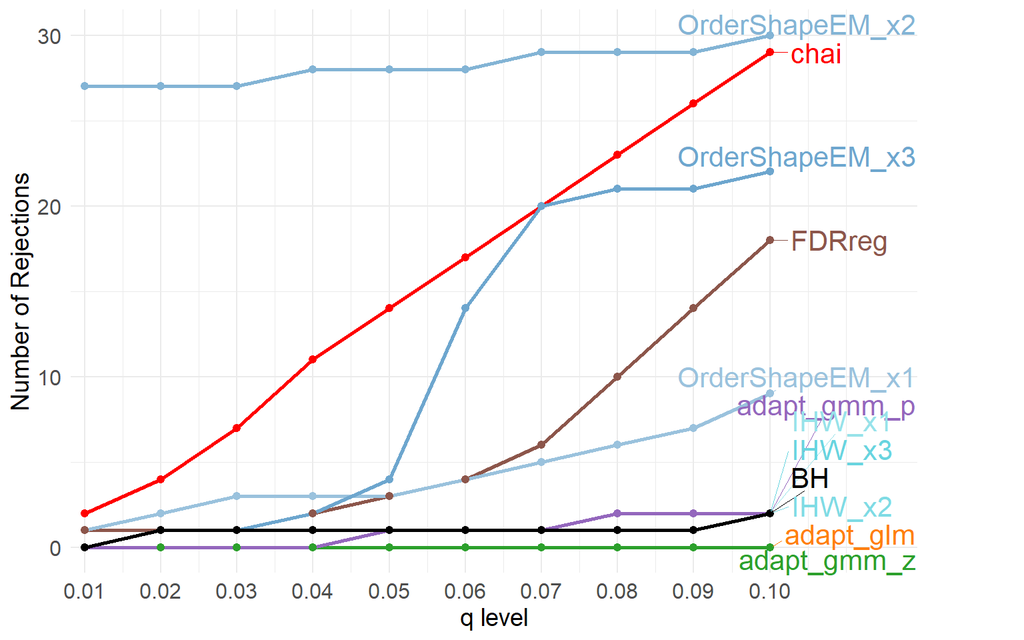

```r
print(p_LLM)
```

Heatmap

```r
# Load the libraries for Heatmap
suppressPackageStartupMessages({
  library(ComplexHeatmap)
  library(circlize)
})
```

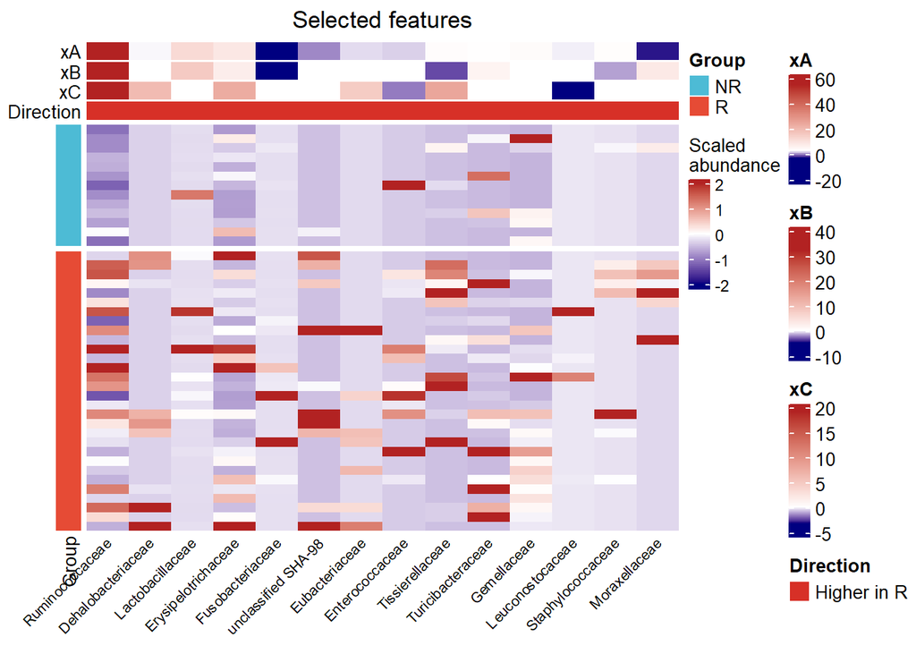

```r
# double check whether the taxon name is corresponding to the OTU name of relative abundance table
stopifnot(df_model$otu_rep == colnames(t_family_abun))

################ Extract selected features ##################
# chai selections at 0.05 FDR level
chai_sel <- clfdrselect(chai_family_llm$clFDR, 0.05, 1)

sel_names <- df_model$taxon_key[chai_sel]
abun_sel <- t_family_abun[, chai_sel, drop = FALSE]
stopifnot(colnames(abun_sel) == df_model$otu_rep[chai_sel])
colnames(abun_sel) <- sel_names
z_sel   <- df_model$z_main[chai_sel]
sideA_sel <- df_model$xA[chai_sel]
sideB_sel <- df_model$xB[chai_sel]
sideC_sel <- df_model$xC[chai_sel]

################## Order rows (subjects) #####################
row_ord <- order(outcome)
abun_sel_ord <- abun_sel[row_ord, , drop = FALSE]
outcome_ord <- outcome[row_ord]

###################### Order columns (features) ###########################
# first features higher in R (z < 0),
# then features higher in NR (z > 0),
# within each group by signal strength

pos_idx <- order(z_sel[z_sel< 0], decreasing = FALSE)
neg_idx <- order(z_sel[z_sel > 0], decreasing = TRUE)

col_ord <- c(pos_idx, neg_idx)

# reorder everything together
abun_sel_ord   <- abun_sel_ord[, col_ord, drop = FALSE]
z_sel_ord      <- z_sel[col_ord]
sideA_sel_ord  <- sideA_sel[col_ord]
sideB_sel_ord  <- sideB_sel[col_ord]
sideC_sel_ord  <- sideC_sel[col_ord]

################ Transform values for heatmap #####################
## Scale each feature across subjects
mat_plot <- scale(abun_sel_ord)

# Column annotations
direction_label <- ifelse(z_sel_ord < 0, "Higher in R", "Higher in NR")

# color for heatmap body
hm_col_fun <- colorRamp2(
  c(-2, 0, 2),
  c("navy", "white", "firebrick")
)

library(ComplexHeatmap)
library(circlize)

# color for side information
col_fun_A <- colorRamp2(
  c(min(sideA_sel_ord, na.rm = TRUE),
    median(sideA_sel_ord, na.rm = TRUE),
    max(sideA_sel_ord, na.rm = TRUE)),
  c("navy", "white", "firebrick")
)

col_fun_B <- colorRamp2(
  c(min(sideB_sel_ord, na.rm = TRUE),
    median(sideB_sel_ord, na.rm = TRUE),
    max(sideB_sel_ord, na.rm = TRUE)),
  c("navy", "white", "firebrick")
)

col_fun_C <- colorRamp2(
  c(min(sideC_sel_ord, na.rm = TRUE),
    median(sideC_sel_ord, na.rm = TRUE),
    max(sideC_sel_ord, na.rm = TRUE)),
  c("navy", "white", "firebrick")
)

top_ha <- HeatmapAnnotation(
  xA = sideA_sel_ord,
  xB = sideB_sel_ord,
  xC = sideC_sel_ord,
  Direction = direction_label,
  col = list(
    xA = col_fun_A,
    xB = col_fun_B,
    xC = col_fun_C,
    Direction = c("Higher in R" = "#D73027",
                  "Higher in NR" = "#4575B4",
                  "Neutral" = "grey70")
  ),
  annotation_name_side = "left",
  annotation_name_gp = gpar(fontsize = 10),
  simple_anno_size = unit(0.35, "cm")
)

############# Row annotation for subject group ################

left_ha <- rowAnnotation(
  Group = outcome_ord,
  col = list(Group = c("R" = "#E64B35", "NR" = "#4DBBD5")),
  annotation_name_gp = gpar(fontsize = 10)
)

######################## Draw heatmap ##########################

ht <- Heatmap(
  mat_plot,
  name = "Scaled\nabundance",
  col = hm_col_fun,

  cluster_rows = FALSE,
  cluster_columns = FALSE,

  show_row_names = FALSE,
  show_column_names = TRUE,
  column_names_gp = gpar(fontsize = 8),
  column_names_rot = 45,

  top_annotation = top_ha,
  left_annotation = left_ha,

  row_split = outcome_ord,   # visually separate R and NR
  row_title = NULL,

  column_title = "Selected features",
  heatmap_legend_param = list(
    title_gp = gpar(fontsize = 10),
    labels_gp = gpar(fontsize = 9)
  )
)

draw(
  ht,
  heatmap_legend_side = "right",
  annotation_legend_side = "right"
)
```